# STAT 331 Portfolio

Author

Garrett Reinhard

**My Grade:** I believe my grade equivalent to course work evidenced below to be an A- .

**Learning Objective Evidence:** In the code chunks below, provide code from Lab or Challenge assignments where you believe you have demonstrated proficiency with the specified learning target. Be sure to specify **where** the code came from (e.g., Lab 4 Question 2).

## Working with Data

**WD-1: I can import data from a *variety* of formats (e.g., csv, xlsx, txt, etc.).**

- `csv` Example 1

```r
#Lab 2 - revised
surveys <- read_csv(here("Week 2", "Lab 2", "Data", "surveys.csv"))
```

- `csv` Example 2

```r
#Code from Challenge 3
teacher_evals <- read_csv(here("Week 3", "Challenge 3", "Data", "teacher_evals.csv"))
```

- `xlsx`

```r
#Practice activity 4
military <- read_xlsx("gov_spending_per_capita.xlsx",
                      sheet = "Share of Govt. spending",
                      skip  = 7,
                      n_max = 190,
                      na = c("xxx", "..", ". .")
                      )
```

**WD-2: I can select necessary columns from a dataset.**

- Example selecting specified columns

```r
#Lab 3 Question 5
teacher_evals_clean <- teachers_evals |>
  rename(sex = gender) |>
  select(course_id,
         teacher_id,
         question_no,
         no_participants,
         resp_share,
         SET_score_avg,
         percent_failed_cur,
         academic_degree,
         seniority,
         sex) |>
  filter(no_participants >= 10) |>
  mutate(teacher_id = as.character(teacher_id),
         seniority = as.character(seniority))
```

- Example removing specified columns

```r
#Lab 3 Question 5 - modified to fit requirements (even though its gross)
teacher_evals_clean <- teachers_evals |>
  rename(sex = gender) |>
  select(-c(stud_grade_avg,
    stud_grade_std,
    stud_grade_var_coef,
    percent_failed,
    stud_grade_avg_cur,
    stud_grade_std_cur,
    stud_grade_var_coef_cur,
    class_duration,
    weekday,
    time_of_day,
    SET_score_1sem,
    maximum_score)) |>
  filter(no_participants >= 10) |>
  mutate(teacher_id = as.character(teacher_id),
         seniority = as.character(seniority))
```

- Example selecting columns based on logical values (e.g., `starts_with()`, `ends_with()`, `contains()`, `where()`)

```r
#Lab 3 Question 8 - modified to fit requirement
teacher_evals_clean |>
  filter(if_any(everything(),  is.na)) |> #everything() checks all columns
  select(ends_with("id"), everything())
```

**WD-3: I can filter rows from a dataframe for a *variety* of data types (e.g., numeric, integer, character, factor, date).**

- Numeric Example 1

```r
#Lab 4 Question 5 - revised
ca_childcare |>
  group_by(census_region, study_year) |>
  summarise(median_mhi_2018 = median(mhi_2018),
            .groups = "drop") |>
  filter(study_year %in% c(2008, 2018)) |>
  pivot_wider(names_from = study_year,
              values_from = median_mhi_2018) |>
  rename("median_household_income_2008" = `2008`,
         "median_household_income_2018" = `2018`) |>
  arrange(desc("median_household_income_2018"))
```

- Numeric Example 2

```r
#Lab 5 Clue #1
person |>
  left_join(y = interview,
            join_by(id == person_id)) |>
  filter((address_street_name == "Northwestern Dr" &
            address_number == max(address_number)) | #find interview for either the person in the last house on Northwestern Dr or Annabel on Franklin Ave
           (address_street_name == "Franklin Ave" &
              str_detect(name, "Annabel"))) |>
  pull(name, transcript)
```

- Character Example 1 (any context)

```r
#Lab 5 Clue #1
person |>
  left_join(y = interview,
            join_by(id == person_id)) |>
  filter((address_street_name == "Northwestern Dr" &
            address_number == max(address_number)) | #find interview for either the person in the last house on Northwestern Dr or Annabel on Franklin Ave
           (address_street_name == "Franklin Ave" &
              str_detect(name, "Annabel"))) |>
  pull(name, transcript)
```

- Character Example 2 (example must use functions from **stringr**)

```r
#Lab 5 Clue #2
get_fit_now_check_in |>
  left_join(y = get_fit_now_member,
            join_by(membership_id == id)) |>
  left_join(y = interview,
            join_by(person_id)) |>
  left_join(y = person,
            join_by(person_id == id)) |>
  left_join(y = drivers_license,
            join_by(license_id == id)) |> #All necessary data joined into one table
  mutate(check_in_date = ymd(check_in_date)) |> #convert date to a Date type
  filter(membership_status == "gold", #gold members have bags
         str_detect(membership_id, "^48Z"), #member id started with 48Z
         str_detect(plate_number, "H42W"), #license plate had H42W
         month(check_in_date, label = TRUE) == "Jan", #Was in the gym on January 9th
         day(check_in_date) == 9) |>
  pull(name.x, transcript)
```

- Date (example must use functions from **lubridate**)

```r
#Lab 5 Clue #2
get_fit_now_check_in |>
  left_join(y = get_fit_now_member,
            join_by(membership_id == id)) |>
  left_join(y = interview,
            join_by(person_id)) |>
  left_join(y = person,
            join_by(person_id == id)) |>
  left_join(y = drivers_license,
            join_by(license_id == id)) |> #All necessary data joined into one table
  mutate(check_in_date = ymd(check_in_date)) |> #convert date to a Date type
  filter(membership_status == "gold", #gold members have bags
         str_detect(membership_id, "^48Z"), #member id started with 48Z
         str_detect(plate_number, "H42W"), #license plate had H42W
         month(check_in_date, label = TRUE) == "Jan", #Was in the gym on January 9th
         day(check_in_date) == 9) |>
  pull(name.x, transcript)
```

**WD-4: I can modify existing variables and create new variables in a dataframe for a *variety* of data types (e.g., numeric, integer, character, factor, date).**

- Numeric Example 1

```r
#Challenge 4 data selection
ca_childcare <- childcare_costs |>
  left_join(y = counties,
            join_by(county_fips_code)) |>
  left_join(y = tax_rev,
            join_by(county_name == entity_name, study_year == year)) |>
  filter(state_name == "California") |>
  mutate(median_familycare = mfcc_infant + mfcc_toddler + mfcc_preschool,
         median_centercare = mc_infant + mc_toddler + mc_preschool) |>
  group_by(study_year) |>
  summarize(median_familycare_price = median(median_familycare),
            median_centercare_price = median(median_centercare),
            .groups = "drop") |>
  pivot_longer( cols = c(median_centercare_price, median_familycare_price),
                names_to = "care_type",
                values_to = "price") |>
  mutate(care_type = case_when(care_type == "median_centercare_price" ~ "Center Care",
                   care_type == "median_familycare_price" ~ "Family Care"))
```

- Numeric Example 2

```r
#Lab 3 Question 7 - Revised
teacher_evals_clean |>
  distinct(teacher_id, academic_degree) |>
  select(academic_degree) |>
  count(academic_degree) |>
  mutate(academic_percent = 100 * n / sum(n)) |>
  arrange(academic_percent)
```

- Factor Example 1 (renaming levels)

```r
#Lab 4 Question 7 - Revised
ca_childcare |>
  pivot_longer(
    cols = c(mc_infant, mc_toddler, mc_preschool),
    names_to = "age_group",
    values_to = "cost") |>
  mutate(
    age_group = fct(age_group, levels = c("mc_infant", "mc_toddler", "mc_preschool")),
    age_group = fct_collapse(.f = age_group,
                              "Infant" = "mc_infant",
                              "Toddler" = "mc_toddler",
                              "Preschool" = "mc_preschool"),
    census_region = fct_reorder2(
      .f = census_region,
      .x = study_year,
      .y = cost )) |>
  ggplot(mapping = aes(x = study_year,
                       y = cost,
                       color = census_region)) +
    geom_point() +
    geom_smooth(method = "loess") +
    facet_wrap(~ age_group, ncol = 3) +
  scale_y_continuous(
      limits = c(100, 500),
      breaks = seq(100, 500, by = 100),
      labels = dollar) +
  scale_x_continuous(
    limits = c(2008, 2018),
    breaks = seq(2008, 2018, by = 2)) +
  labs(title = "Weekly Median Price for Center-Based Childcare ($)",
       x = "Study Year",
       y = NULL,
       color = str_to_title("Census Region")) +
  theme_bw() +
  theme(panel.spacing =  grid::unit(10, "pt"),
        axis.text.x = element_text(size = 6))
```

- Factor Example 2 (reordering levels)

```r
#Lab 4 Question 7 - Revised
ca_childcare |>
  pivot_longer(
    cols = c(mc_infant, mc_toddler, mc_preschool),
    names_to = "age_group",
    values_to = "cost") |>
  mutate(
    age_group = fct(age_group, levels = c("mc_infant", "mc_toddler", "mc_preschool")),
    age_group = fct_collapse(.f = age_group,
                              "Infant" = "mc_infant",
                              "Toddler" = "mc_toddler",
                              "Preschool" = "mc_preschool"),
    census_region = fct_reorder2(
      .f = census_region,
      .x = study_year,
      .y = cost )) |>
  ggplot(mapping = aes(x = study_year,
                       y = cost,
                       color = census_region)) +
    geom_point() +
    geom_smooth(method = "loess") +
    facet_wrap(~ age_group, ncol = 3) +
  scale_y_continuous(
      limits = c(100, 500),
      breaks = seq(100, 500, by = 100),
      labels = dollar) +
  scale_x_continuous(
    limits = c(2008, 2018),
    breaks = seq(2008, 2018, by = 2)) +
  labs(title = "Weekly Median Price for Center-Based Childcare ($)",
       x = "Study Year",
       y = NULL,
       color = str_to_title("Census Region")) +
  theme_bw() +
  theme(panel.spacing =  grid::unit(10, "pt"),
        axis.text.x = element_text(size = 6))
```

- Character (example must use functions from **stringr**)

```r
#Code from Lab 9
unformatted_tbl <- evals_fct |>
  mutate(
    seniority = case_when(
      seniority <= 4 ~ "Junior",
      seniority > 8 ~ "Very Senior",
      .default = "Senior"
    ),
    sex = str_to_title(sex),
    academic_degree = case_when(
      academic_degree == "dr" ~ "Doctorate",
      academic_degree == "ma" ~ "Masters",
      academic_degree == "no_dgr" ~ "No Degree",
      academic_degree == "prof" ~ "Tenured Professor"
    )
  ) |> distinct(
    teacher_id,
    seniority,
    sex,
    academic_degree
  ) |> pivot_longer(
    cols = c(seniority, sex, academic_degree),
    names_to = "variable",
    values_to = "level"
  ) |> group_by(
    variable,
    level
  ) |> summarise(
    n = n_distinct(teacher_id),
    .groups = "drop_last"
  ) |> mutate(
    variable = str_to_title(variable),
    prop = n / sum(n)
  ) |> ungroup()
```

- Date (example must use functions from **lubridate**)

```r
#Lab 5 Clue #3
new_suspect <- person |>
  left_join(y = drivers_license,
            join_by(license_id == id)) |>
  left_join(y = income,
            join_by(ssn)) |>
  left_join(y = facebook_event_checkin,
            join_by(id == person_id)) |> #combined necessary data into one table
  mutate(date = ymd(date)) |> #Convert date to a date type
  filter(gender == "female", #employer is female
         hair_color == "red", # red hair
         car_make == "Tesla", #drives a tesla model s
         car_model == "Model S",
         height %in% c(65:67), #height is in this range
         event_name == "SQL Symphony Concert", #went to this concert in December 2017
         month(date, label = TRUE) == "Dec",
         year(date) == 2017) |>
  add_count(id) |> #Count each person who went to the concert
  filter(n == 3) |> #Employer went 3 times
  select(name, id, annual_income) |> #verify for high income
  distinct()
```

**WD-5: I can use mutating joins to combine multiple dataframes.**

- `left_join()` Example 1

```r
#Lab 5 Clue #2
get_fit_now_check_in |>
  left_join(y = get_fit_now_member,
            join_by(membership_id == id)) |>
  left_join(y = interview,
            join_by(person_id)) |>
  left_join(y = person,
            join_by(person_id == id)) |>
  left_join(y = drivers_license,
            join_by(license_id == id)) |> #All necessary data joined into one table
  mutate(check_in_date = ymd(check_in_date)) |> #convert date to a Date type
  filter(membership_status == "gold", #gold members have bags
         str_detect(membership_id, "^48Z"), #member id started with 48Z
         str_detect(plate_number, "H42W"), #license plate had H42W
         month(check_in_date, label = TRUE) == "Jan", #Was in the gym on January 9th
         day(check_in_date) == 9) |>
  pull(name.x, transcript)
```

- `right_join()` Example 1

```r
#Lab 5 Clue #3 - modified to fit requirement
interview |>
  right_join(person,
            join_by(person_id == id)) |>
  filter(name == "Miranda Priestly") |>
  pull(transcript) #No interview
```

- `left_join()` **or** `right_join()` Example 2

```r
#Lab 5 Clue #1
person |>
    filter((address_street_name == "Northwestern Dr" &
            address_number == max(address_number)) | #find interview for either the person in the last house on Northwestern Dr or Annabel on Franklin Ave
           (address_street_name == "Franklin Ave" &
              str_detect(name, "Annabel"))) |>
  left_join(y = interview,
            join_by(id == person_id)) |>
  pull(name, transcript)
```

- `inner_join()` Example 1

```r
#Lab 5 Clue #1 - modified to fit requirement
person |>
    filter((address_street_name == "Northwestern Dr" &
            address_number == max(address_number)) | #find interview for either the person in the last house on Northwestern Dr or Annabel on Franklin Ave
           (address_street_name == "Franklin Ave" &
              str_detect(name, "Annabel"))) |>
  inner_join(y = interview,
            join_by(id == person_id)) |>
  pull(name, transcript)
```

- `inner_join()` Example 2

```r
#Lab 5 Clue #2 - Modified to fit requirement
get_fit_now_check_in |>
  inner_join(y = get_fit_now_member,
            join_by(membership_id == id)) |>
  inner_join(y = interview,
            join_by(person_id)) |>
  inner_join(y = person,
            join_by(person_id == id)) |>
  inner_join(y = drivers_license,
            join_by(license_id == id)) |> #All necessary data joined into one table
  mutate(check_in_date = ymd(check_in_date)) |> #convert date to a Date type
  filter(membership_status == "gold", #gold members have bags
         str_detect(membership_id, "^48Z"), #member id started with 48Z
         str_detect(plate_number, "H42W"), #license plate had H42W
         month(check_in_date, label = TRUE) == "Jan", #Was in the gym on January 9th
         day(check_in_date) == 9) |>
  pull(name.x, transcript)
```

**WD-6: I can use filtering joins to filter rows from a dataframe.**

- `semi_join()`

```r
#Lab 5 Clue #3 - modified to fit requirement
interview |>
  semi_join(new_suspect,
            join_by(person_id == id)) |>
  pull(transcript) #No interview
```

- `anti_join()`

```r
#Lab 5 Clue #3 - modified to fit requirement
person |>
  filter(name == "Miranda Priestly") |>
  anti_join(interview, by = join_by(id == person_id))
```

**WD-7: I can pivot dataframes from long to wide and visa versa**

- `pivot_longer()`

```r
#Challenge 4 data selection
ca_childcare <- childcare_costs |>
  left_join(y = counties,
            join_by(county_fips_code)) |>
  left_join(y = tax_rev,
            join_by(county_name == entity_name, study_year == year)) |>
  filter(state_name == "California") |>
  mutate(median_familycare = mfcc_infant + mfcc_toddler + mfcc_preschool,
         median_centercare = mc_infant + mc_toddler + mc_preschool) |>
  group_by(study_year) |>
  summarize(median_familycare_price = median(median_familycare),
            median_centercare_price = median(median_centercare),
            .groups = "drop") |>
  pivot_longer( cols = c(median_centercare_price, median_familycare_price),
                names_to = "care_type",
                values_to = "price") |>
  mutate(care_type = case_when(care_type == "median_centercare_price" ~ "Center Care",
                   care_type == "median_familycare_price" ~ "Family Care"))
```

- `pivot_wider()`

```r
#Lab 4 Question 5 - revised
ca_childcare |>
  group_by(census_region, study_year) |>
  summarise(median_mhi_2018 = median(mhi_2018),
            .groups = "drop") |>
  filter(study_year %in% c(2008, 2018)) |>
  pivot_wider(names_from = study_year,
              values_from = median_mhi_2018) |>
  rename("median_household_income_2008" = `2008`,
         "median_household_income_2018" = `2018`) |>
  arrange(desc("median_household_income_2018"))
```

## Reproducibility

**R-1: I can create professional looking, reproducible analyses using RStudio projects, Quarto documents, and the here package.**

The following assignments satisfy the above criteria:

- Lab 5
- Challenge 4
- Lab 4
- Lab 3
- Challenge 3
- Lab 10
- Lab 9

**R-2: I can write well documented and tidy code.**

- Example of **ggplot2** plotting

```r
#Challenge 4 - Revised
ca_childcare |>
  ggplot(mapping = aes(x = study_year,
                       y = price)) +
  geom_point(show.legend = FALSE) +
  geom_smooth(method = "lm",
              fill = "dodgerblue3",
              show.legend = FALSE,
              color = "coral2") +
  facet_wrap(~ care_type, ncol = 2) +
  scale_x_continuous(limits = c(2008, 2018),
                     breaks = seq(2008, 2018, by = 2)) +
  labs(x = "Study Year",
       y = NULL,
       subtitle = "Median Price of Childcare",
       title = "Median Weekly Price of Family Childcare vs. Center-based Childcare in CA") +
  theme_bw() +
  theme(panel.grid.major = element_line(color = "gray45"),
        panel.grid.minor = element_line(color = "gray70"),
        panel.background = element_rect(fill = "lightsteelblue2"),
        strip.background = element_rect(fill = "pink"))
```

- Example of **dplyr** pipeline

```r
#Lab 5 Clue #3
person |>
  left_join(y = drivers_license,
            join_by(license_id == id)) |>
  left_join(y = income,
            join_by(ssn)) |>
  left_join(y = facebook_event_checkin,
            join_by(id == person_id)) |> #combined necessary data into one table
  mutate(date = ymd(date)) |> #Convert date to a date type
  filter(gender == "female", #employer is female
         hair_color == "red", # red hair
         car_make == "Tesla", #drives a tesla model s
         car_model == "Model S",
         height %in% c(65:67), #height is in this range
         event_name == "SQL Symphony Concert", #went to this concert in December 2017
         month(date, label = TRUE) == "Dec",
         year(date) == 2017) |>
  add_count(id) |> #Count each person who went to the concert
  filter(n == 3) |> #Employer went 3 times
  select(name, annual_income) |> #verify for high income
  distinct()
```

- Example of function formatting

```r
# Lab 10 question 8
mycifun <- function(beta0, beta1, n){
  stopifnot(is.numeric(beta0))
  stopifnot(is.numeric(beta1))
  stopifnot(is.numeric(n))

  x = runif(n, 0, 1)
  ep = rnorm(n, mean = 0, sd = 1)
  y = beta0 + beta1 * x + ep

  data_frame = data.frame(x = x, y = y)
  lm_model = lm(y ~ x, data = data_frame)
  tidy_model = tidy(conf.int = TRUE, conf.level = 0.95, x = lm_model)
  tidy_model |>
    mutate(cover = ifelse(term == "x" & beta1 >= conf.low & beta1 <= conf.high, 1, 0)) |>
    filter(
      term == "x"
    ) |>
    select(
      estimate,
      conf.low,
      conf.high,
      cover
    )
}
```

**R-3: I can write robust programs that are resistant to changes in inputs.**

- Example (any context)

```r
#Lab 4 Question 7
ca_childcare |>
  pivot_longer(
    cols = c(mc_infant, mc_toddler, mc_preschool),
    names_to = "age_group",
    values_to = "cost") |>
  mutate(
    age_group = fct(age_group, levels = c("mc_infant", "mc_toddler", "mc_preschool")),
    age_group = fct_collapse(.f = age_group,
                              "Infant" = "mc_infant",
                              "Toddler" = "mc_toddler",
                              "Preschool" = "mc_preschool"),
    census_region = fct_reorder2(
      .f = census_region,
      .x = study_year,
      .y = cost )) |>
  ggplot(mapping = aes(x = study_year,
                       y = cost,
                       color = census_region)) +
    geom_point() +
    geom_smooth(method = "loess") +
    facet_wrap(~ age_group, ncol = 3) +
  scale_y_continuous(
      limits = c(100, 500),
      breaks = seq(100, 500, by = 100),
      labels = dollar) +
  scale_x_continuous(
    limits = c(2008, 2018),
    breaks = seq(2008, 2018, by = 2)) +
  labs(title = "Weekly Median Price for Center-Based Childcare ($)",
       x = "Study Year",
       y = NULL,
       color = str_to_title("Census Region")) +
  theme_bw() +
  theme(panel.spacing =  grid::unit(10, "pt"),
        axis.text.x = element_text(size = 6))
```

- Example (function stops)

```r
#Lab 10 question 8
mycifun <- function(beta0, beta1, n){
  stopifnot(is.numeric(beta0))
  stopifnot(is.numeric(beta1))
  stopifnot(is.numeric(n))

  x = runif(n, 0, 1)
  ep = rnorm(n, mean = 0, sd = 1)
  y = beta0 + beta1 * x + ep

  data_frame = data.frame(x = x, y = y)
  lm_model = lm(y ~ x, data = data_frame)
  tidy_model = tidy(conf.int = TRUE, conf.level = 0.95, x = lm_model)
  tidy_model |>
    mutate(cover = ifelse(term == "x" & beta1 >= conf.low & beta1 <= conf.high, 1, 0)) |>
    filter(
      term == "x"
    ) |>
    select(
      estimate,
      conf.low,
      conf.high,
      cover
    )
}
```

## Data Visualization & Summarization

**DVS-1: I can create visualizations for a *variety* of variable types (e.g., numeric, character, factor, date)**

- At least two numeric variables

```r
#Lab 4 Question 8 - revised
ca_childcare |>
  ggplot(mapping = aes(x = mhi_2018, y = mfcc_infant)) +
  geom_point() +
  geom_smooth(method = "lm") +
  theme_light() +
  scale_x_continuous(labels = dollar) +
  labs(x = "Median Household Income (2018 Dollars)",
       y = NULL,
       title = "Median Weekly Full-Time Center Based Childcare for Infants")
```

- At least one numeric variable and one categorical variable

```r
#Lab 2 Question 16 - revised
ggplot(data = surveys,
    mapping = aes(y = species, x = weight)) +
  geom_boxplot(outliers = FALSE) +
  geom_jitter(color = "steelblue", alpha = 0.3) +
  labs(x = "Weight (g)", y = "Species") +
  theme(panel.border = element_rect(color = "steelblue", fill = NA),
        axis.title.y = element_text(margin = margin(t = 0, b = 0, r = 15, l = 0)),
        axis.text.y = element_text(margin = margin(t= 0, b = 0, r = 10, l = 0)),
        axis.title.x = element_text(margin = margin(t = 5, b = 0, r = 0, l = 0)))
```

- At least two categorical variables

```r
# Challenge 3 Question 2 - revised
ggplot(data = teacher_evals_compare,
       mapping = aes(x = sen_level, fill = SET_level)) +
  geom_bar(position = "fill") +
  geom_text(
    aes(label = scales::label_percent(accuracy = 1)(after_stat(prop)),
        group = SET_level),
    stat = "count",
    position = position_fill(vjust = 0.5),
    color = "white") +
  scale_y_continuous(labels = scales::label_percent()) +
  labs(x = "Years of Experience",
       y = NULL,
       fill = "Evaluation Rating",
       title = "Evaluation of Teachers' Use of Activities") +
  theme_light() +
  theme(legend.position = "top") +
  scale_fill_brewer(palette = "Set1")
```

- Dates (time series plot)

```r
#Challenge 4 - Revised
ca_childcare |>
  ggplot(mapping = aes(x = study_year,
                       y = price)) +
  geom_point(show.legend = FALSE) +
  geom_smooth(method = "lm",
              fill = "dodgerblue3",
              show.legend = FALSE,
              color = "coral2") +
  facet_wrap(~ care_type, ncol = 2) +
  scale_x_continuous(limits = c(2008, 2018),
                     breaks = seq(2008, 2018, by = 2)) +
  labs(x = "Study Year",
       y = NULL,
       subtitle = "Median Price of Childcare",
       title = "Median Weekly Price of Family Childcare vs. Center-based Childcare in CA") +
  theme_bw() +
  theme(panel.grid.major = element_line(color = "gray45"),
        panel.grid.minor = element_line(color = "gray70"),
        panel.background = element_rect(fill = "lightsteelblue2"),
        strip.background = element_rect(fill = "pink"))
```

**DVS-2: I use plot modifications to make my visualization clear to the reader.**

- I can modify my plot theme to be more readable

```r
#Lab 4 Question 7 - Revised
ca_childcare |>
  pivot_longer(
    cols = c(mc_infant, mc_toddler, mc_preschool),
    names_to = "age_group",
    values_to = "cost") |>
  mutate(
    age_group = fct(age_group, levels = c("mc_infant", "mc_toddler", "mc_preschool")),
    age_group = fct_collapse(.f = age_group,
                              "Infant" = "mc_infant",
                              "Toddler" = "mc_toddler",
                              "Preschool" = "mc_preschool"),
    census_region = fct_reorder2(
      .f = census_region,
      .x = study_year,
      .y = cost )) |>
  ggplot(mapping = aes(x = study_year,
                       y = cost,
                       color = census_region)) +
    geom_point() +
    geom_smooth(method = "loess") +
    facet_wrap(~ age_group, ncol = 3) +
  scale_y_continuous(
      limits = c(100, 500),
      breaks = seq(100, 500, by = 100),
      labels = dollar) +
  scale_x_continuous(
    limits = c(2008, 2018),
    breaks = seq(2008, 2018, by = 2)) +
  labs(title = "Weekly Median Price for Center-Based Childcare ($)",
       x = "Study Year",
       y = NULL,
       color = str_to_title("Census Region")) +
  theme_bw() +
  theme(panel.spacing =  grid::unit(10, "pt"),
        axis.text.x = element_text(size = 6))
```

- I can modify my colors to be accessible to anyone’s eyes

```r
#Challenge 4 - Revised
ca_childcare |>
  ggplot(mapping = aes(x = study_year,
                       y = price)) +
  geom_point(show.legend = FALSE) +
  geom_smooth(method = "lm",
              fill = "dodgerblue3",
              show.legend = FALSE,
              color = "coral2") +
  facet_wrap(~ care_type, ncol = 2) +
  scale_x_continuous(limits = c(2008, 2018),
                     breaks = seq(2008, 2018, by = 2)) +
  labs(x = "Study Year",
       y = NULL,
       subtitle = "Median Price of Childcare",
       title = "Median Weekly Price of Family Childcare vs. Center-based Childcare in CA") +
  theme_bw() +
  theme(panel.grid.major = element_line(color = "gray45"),
        panel.grid.minor = element_line(color = "gray70"),
        panel.background = element_rect(fill = "lightsteelblue2"),
        strip.background = element_rect(fill = "pink"))
```

- I can modify my plot titles to clearly communicate the data context

```r
#Lab 4 Question 7 - Revised
ca_childcare |>
  pivot_longer(
    cols = c(mc_infant, mc_toddler, mc_preschool),
    names_to = "age_group",
    values_to = "cost") |>
  mutate(
    age_group = fct(age_group, levels = c("mc_infant", "mc_toddler", "mc_preschool")),
    age_group = fct_collapse(.f = age_group,
                              "Infant" = "mc_infant",
                              "Toddler" = "mc_toddler",
                              "Preschool" = "mc_preschool"),
    census_region = fct_reorder2(
      .f = census_region,
      .x = study_year,
      .y = cost )) |>
  ggplot(mapping = aes(x = study_year,
                       y = cost,
                       color = census_region)) +
    geom_point() +
    geom_smooth(method = "loess") +
    facet_wrap(~ age_group, ncol = 3) +
  scale_y_continuous(
      limits = c(100, 500),
      breaks = seq(100, 500, by = 100),
      labels = dollar) +
  scale_x_continuous(
    limits = c(2008, 2018),
    breaks = seq(2008, 2018, by = 2)) +
  labs(title = "Weekly Median Price for Center-Based Childcare ($)",
       x = "Study Year",
       y = NULL,
       color = str_to_title("Census Region")) +
  theme_bw() +
  theme(panel.spacing =  grid::unit(10, "pt"),
        axis.text.x = element_text(size = 6))
```

- I can modify the text in my plot to be more readable

```r
#Lab 4 Question 7 - Revised
ca_childcare |>
  pivot_longer(
    cols = c(mc_infant, mc_toddler, mc_preschool),
    names_to = "age_group",
    values_to = "cost") |>
  mutate(
    age_group = fct(age_group, levels = c("mc_infant", "mc_toddler", "mc_preschool")),
    age_group = fct_collapse(.f = age_group,
                              "Infant" = "mc_infant",
                              "Toddler" = "mc_toddler",
                              "Preschool" = "mc_preschool"),
    census_region = fct_reorder2(
      .f = census_region,
      .x = study_year,
      .y = cost )) |>
  ggplot(mapping = aes(x = study_year,
                       y = cost,
                       color = census_region)) +
    geom_point() +
    geom_smooth(method = "loess") +
    facet_wrap(~ age_group, ncol = 3) +
  scale_y_continuous(
      limits = c(100, 500),
      breaks = seq(100, 500, by = 100),
      labels = dollar) +
  scale_x_continuous(
    limits = c(2008, 2018),
    breaks = seq(2008, 2018, by = 2)) +
  labs(title = "Weekly Median Price for Center-Based Childcare ($)",
       x = "Study Year",
       y = NULL,
       color = str_to_title("Census Region")) +
  theme_bw() +
  theme(panel.spacing =  grid::unit(10, "pt"),
        axis.text.x = element_text(size = 6))
```

- I can reorder my legend to align with the colors in my plot

```r
#Lab 4 Question 7 - Revised
ca_childcare |>
  pivot_longer(
    cols = c(mc_infant, mc_toddler, mc_preschool),
    names_to = "age_group",
    values_to = "cost") |>
  mutate(
    age_group = fct(age_group, levels = c("mc_infant", "mc_toddler", "mc_preschool")),
    age_group = fct_collapse(.f = age_group,
                              "Infant" = "mc_infant",
                              "Toddler" = "mc_toddler",
                              "Preschool" = "mc_preschool"),
    census_region = fct_reorder2(
      .f = census_region,
      .x = study_year,
      .y = cost )) |>
  ggplot(mapping = aes(x = study_year,
                       y = cost,
                       color = census_region)) +
    geom_point() +
    geom_smooth(method = "loess") +
    facet_wrap(~ age_group, ncol = 3) +
  scale_y_continuous(
      limits = c(100, 500),
      breaks = seq(100, 500, by = 100),
      labels = dollar) +
  scale_x_continuous(
    limits = c(2008, 2018),
    breaks = seq(2008, 2018, by = 2)) +
  labs(title = "Weekly Median Price for Center-Based Childcare ($)",
       x = "Study Year",
       y = NULL,
       color = str_to_title("Census Region")) +
  theme_bw() +
  theme(panel.spacing =  grid::unit(10, "pt"),
        axis.text.x = element_text(size = 6))
```

**DVS-3: I show creativity in my visualizations**

- I can use non-standard colors (Example 1)

```r
#Challenge 4 - Revised
ca_childcare |>
  ggplot(mapping = aes(x = study_year,
                       y = price)) +
  geom_point(show.legend = FALSE) +
  geom_smooth(method = "lm",
              fill = "dodgerblue3",
              show.legend = FALSE,
              color = "coral2") +
  facet_wrap(~ care_type, ncol = 2) +
  scale_x_continuous(limits = c(2008, 2018),
                     breaks = seq(2008, 2018, by = 2)) +
  labs(x = "Study Year",
       y = NULL,
       subtitle = "Median Price of Childcare",
       title = "Median Weekly Price of Family Childcare vs. Center-based Childcare in CA") +
  theme_bw() +
  theme(panel.grid.major = element_line(color = "gray45"),
        panel.grid.minor = element_line(color = "gray70"),
        panel.background = element_rect(fill = "lightsteelblue2"),
        strip.background = element_rect(fill = "pink"))
```

- I can use non-standard colors (Example 2)

```r
#Lab 8 Question 4
style_plot <- function(plot, theme_fn = theme_minimal, palette = RColorBrewer::brewer.pal(8, "Set2"), aesthetic){

  if(aesthetic == "fill"){
    result <- plot +
      theme_fn() +
      scale_fill_manual(values = palette)
  } else if (aesthetic == "color"){
    result <- plot +
      theme_fn() +
      scale_color_manual(values = palette)
  } else {
    stop("Usage: aesthetic must be 'color' or 'fill'")
  }
  return(result)
}
```

- I can use annotations (e.g., `geom_text()`)

```r
# Challenge 3 Question 2 - revised to fit requirement
ggplot(data = teacher_evals_compare,
       mapping = aes(x = sen_level, fill = SET_level)) +
  geom_bar(position = "fill") +
  geom_text(
    aes(label = label_percent(accuracy = 1)(after_stat(prop)),
        group = SET_level),
    stat = "count",
    position = position_fill(vjust = 0.5),
    color = "white") +
  scale_y_continuous(labels = scales::label_percent()) +
  labs(x = "Years of Experience",
       y = NULL,
       fill = "Evaluation Rating",
       title = "Evaluation of Teachers' Use of Activities") +
  theme_light() +
  theme(legend.position = "top") +
  scale_fill_brewer(palette = "Set1")
```

- I can choose creative geometries (e.g., `geom_segment()`, `geom_ribbon)()`)

```r
# Lab 10 Question 13 - revised
bound_dat |>
  mutate(sim_num = row_number()) |>
ggplot(aes(y = sim_num, x = estimate)) +
  geom_errorbar(aes(xmin = conf.low, xmax = conf.high, color = factor(cover)), height = 0.3, linewidth = 0.8) +
  geom_vline(xintercept = 0.5, linetype = "dashed") +
  scale_color_manual(
    values = c("0" = "red", "1" = "skyblue"),
    labels = c("Does not include true slope", "Includes true slope"),
    guide = "none"
  ) +
  labs(
    title = "95% Confidence Intervals of Estimated Regression Slope\nfor 1000 Simulated Datasets",
    subtitle = "CIs that do not include the population slope are highlighted in red",
    x = "Slope Coefficient Estimate",
    y = NULL
  ) +
  theme_bw() +
  theme(
    plot.title = element_text(face = "bold"),
    plot.subtitle = element_text(size = 11, color= "red")
  )
```

**DVS-4: I can calculate numerical summaries of variables.**

- Example using `summarize()`

```r
#Lab 9 Question 5
unformatted_tbl <- evals_fct |>
  mutate(
    seniority = case_when(
      seniority <= 4 ~ "Junior",
      seniority > 8 ~ "Very Senior",
      .default = "Senior"
    ),
    sex = str_to_title(sex),
    academic_degree = case_when(
      academic_degree == "dr" ~ "Doctorate",
      academic_degree == "ma" ~ "Masters",
      academic_degree == "no_dgr" ~ "No Degree",
      academic_degree == "prof" ~ "Tenured Professor"
    )
  ) |> distinct(
    teacher_id,
    seniority,
    sex,
    academic_degree
  ) |> pivot_longer(
    cols = c(seniority, sex, academic_degree),
    names_to = "variable",
    values_to = "level"
  ) |> group_by(
    variable,
    level
  ) |> summarise(
    n = n_distinct(teacher_id),
    .groups = "drop_last"
  ) |> mutate(
    variable = str_to_title(variable),
    prop = n / sum(n)
  ) |> ungroup()
```

- Example using `across()`

```r
#Lab 3 Question 6 - revised
teacher_evals_clean |>
  summarize(
    across(
      .cols = c(course_id, teacher_id),
      .fns = ~ n_distinct(.x)
    )
  )
```

**DVS-5: I can find summaries of variables across multiple groups.**

- Example 1

```r
#Lab 3 Question 9
teacher_evals_clean |>
  group_by(teacher_id, course_id) |>
  summarize(n_questions = n_distinct(question_no), .groups = "drop") |>
  #at this point each teacher course combo has their question count
  filter(n_questions == 9) |>
  count()
```

- Example 2

```r
#Lab 4 Question 5 - revised
ca_childcare |>
  group_by(census_region, study_year) |>
  summarise(median_mhi_2018 = median(mhi_2018),
            .groups = "drop") |>
  filter(study_year %in% c(2008, 2018)) |>
  pivot_wider(names_from = study_year,
              values_from = median_mhi_2018) |>
  rename("median_household_income_2008" = `2008`,
         "median_household_income_2018" = `2018`) |>
  arrange(desc("median_household_income_2018"))
```

**DVS-6: I can create tables which make my summaries clear to the reader.**

- I can modify my column names to clearly communicate the data context

```r
#Lab 4 Question 5 - revised
ca_childcare |>
  group_by(census_region, study_year) |>
  summarise(median_mhi_2018 = median(mhi_2018),
            .groups = "drop") |>
  filter(study_year %in% c(2008, 2018)) |>
  pivot_wider(names_from = study_year,
              values_from = median_mhi_2018) |>
  rename("median_household_income_2008" = `2008`,
         "median_household_income_2018" = `2018`) |>
  arrange(desc("median_household_income_2018"))
```

- I can modify the text in my table to be more readable (e.g., bold face for column headers)

```r
#Lab 9 Question 6
unformatted_tbl |>
  arrange(variable, level) |>
  gt(
    rowname_col = "level",
    groupname_col = "variable"
  ) |>
  cols_label(
    level = "Demographic",
    n = "Count",
    prop = "%"
  ) |>
  fmt_percent(
    columns = prop,
    decimals = 2
  ) |>
  tab_header(
    title = "Demographics of Professors",
    subtitle = "Student Evaluations at the University of Poland, Warsaw in 2020"
  ) |>
  tab_spanner(
    label = "Professors",
    columns = c(n, prop)
  ) |> tab_style(
  style = list(
    cell_fill(color = "gray"),
    cell_text(weight = "bold", color = "#333333")
  ),
  locations = cells_row_groups()
  )
```

- I can arrange my table to have an intuitive ordering

```r
#Lab 4 Question 5 - revised
ca_childcare |>
  group_by(census_region, study_year) |>
  summarise(median_mhi_2018 = median(mhi_2018),
            .groups = "drop") |>
  filter(study_year %in% c(2008, 2018)) |>
  pivot_wider(names_from = study_year,
              values_from = median_mhi_2018) |>
  rename("median_household_income_2008" = `2008`,
         "median_household_income_2018" = `2018`) |>
  arrange(desc("median_household_income_2018"))
```

**DVS-7: I show creativity in my tables.**

- I can use non-default colors

```r
#Lab 9 Question 8
missing_vals |>
  gt() |>
  cols_label(
    variable = "Measurement Variable",
    missing_value = "Missing Values"
  ) |>
  tab_header(
    title = "Number of Missing Values for Fish Measurements",
    subtitle = "Data Collected from 1989 to 2006 on the Blackfoot Fish River in Montana"
  ) |> tab_style(
  style = list(
    cell_fill(color = "gray"),
    cell_text(weight = "bold", color = "#333333")
  ),
  locations = cells_column_labels()
  ) |> data_color(
    columns = missing_value,
    fn = function(x) {
      ifelse(x == 0, "cyan4", "orangered")
    }
  )
```

- I can modify the layout of my table to be more readable (e.g., `pivot_longer()` or `pivot_wider()`)

```r
#Lab 9 Question 5
unformatted_tbl <- evals_fct |>
  mutate(
    seniority = case_when(
      seniority <= 4 ~ "Junior",
      seniority > 8 ~ "Very Senior",
      .default = "Senior"
    ),
    sex = str_to_title(sex),
    academic_degree = case_when(
      academic_degree == "dr" ~ "Doctorate",
      academic_degree == "ma" ~ "Masters",
      academic_degree == "no_dgr" ~ "No Degree",
      academic_degree == "prof" ~ "Tenured Professor"
    )
  ) |> distinct(
    teacher_id,
    seniority,
    sex,
    academic_degree
  ) |> pivot_longer(
    cols = c(seniority, sex, academic_degree),
    names_to = "variable",
    values_to = "level"
  ) |> group_by(
    variable,
    level
  ) |> summarise(
    n = n_distinct(teacher_id),
    .groups = "drop_last"
  ) |> mutate(
    variable = str_to_title(variable),
    prop = n / sum(n)
  ) |> ungroup()
```

## Program Efficiency

**PE-1: I can write concise code which does not repeat itself.**

- using a single function call with multiple inputs (rather than multiple function calls)

```r
#Lab 5 Clue #3
new_suspect <- person |>
  left_join(y = drivers_license,
            join_by(license_id == id)) |>
  left_join(y = income,
            join_by(ssn)) |>
  left_join(y = facebook_event_checkin,
            join_by(id == person_id)) |> #combined necessary data into one table
  mutate(date = ymd(date)) |> #Convert date to a date type
  filter(gender == "female", #employer is female
         hair_color == "red", # red hair
         car_make == "Tesla", #drives a tesla model s
         car_model == "Model S",
         height %in% c(65:67), #height is in this range
         event_name == "SQL Symphony Concert", #went to this concert in December 2017
         month(date, label = TRUE) == "Dec",
         year(date) == 2017) |>
  add_count(id) |> #Count each person who went to the concert
  filter(n == 3) |> #Employer went 3 times
  select(name, id, annual_income) |> #verify for high income
  distinct()
```

- using `across()`

```r
#Lab 3 Question 5 - revised
teacher_evals_clean <- teachers_evals |>
  rename(sex = gender) |>
  select(-c(stud_grade_avg,
    stud_grade_std,
    stud_grade_var_coef,
    percent_failed,
    stud_grade_avg_cur,
    stud_grade_std_cur,
    stud_grade_var_coef_cur,
    class_duration,
    weekday,
    time_of_day,
    SET_score_1sem,
    maximum_score)) |>
  filter(no_participants >= 10) |>
  mutate(teacher_id = as.character(teacher_id),
         across(
           .cols = c(teacher_id,
                     seniority),
           .fns = ~ as.numeric(.x)))
```

- using functions from the `map()` family

```r
# Lab 9 Question 7
missing_vals <- fish |>
  map_int(~ sum(is.na(.x))) |>
  enframe(name = "variable",
          value = "missing_value") |>
  arrange(missing_value)
```

**PE-2: I can write functions to reduce repetition in my code.**

- Example 1: Function that operates on vectors

```r
# Lab 7 Question 4
rescale_01 <- function(vec) {
  if(!is.numeric(vec)){
    stop("Vector type must be numeric")
  }
  if(length(vec) <= 1){
    stop("Vector must contain at least two elements")
  }
  rng <- range(vec, na.rm = TRUE)
  (vec - rng[1]) / (rng[2] - rng[1])
}
```

- Example 2: Function that operates on data frames

```r
# Lab 8 Question 2 - revised
pivot_table <- function(df, row, col){
  stopifnot(is.data.frame(df))
  result <- df |>
      count({{row}}, {{col}}) |>
    pivot_wider(
      names_from = {{col}},
      values_from = n
    )
  return(result)
}
```

- Example 3: Function that operates on vectors *or* data frames

```r
# Lab 8 Question 3 - revised
make_boxplot <- function(df, x, y){
  stopifnot(is.data.frame(df))

  x_name <- as_label(enquo(x))
  y_name <- as_label(enquo(y))

  reformat <- function(str){
    str |>
      str_replace_all("_", " ") |>
      str_to_title() |>
      str_squish() |>
      str_replace("Mm", "(mm)")
  }
  x_lab <- reformat(x_name)
  y_lab <- reformat(y_name)

  title <- str_c(y_lab, "by", x_lab, sep = " ") |>
    str_remove("\\(mm\\)\\ ")

  plot <-
    df |>
    rescale_column({{y}}) |>
      ggplot(
        mapping = aes(x = {{x}}, y = {{y}}, fill = {{x}})
      ) +
      geom_boxplot() +
      geom_jitter(alpha = 0.2) +
      labs(
        x = x_lab,
        y = "",
        title = title,
        subtitle = y_lab,
      ) +
      guides(fill = "none",
             alpha = "none")

  return(plot)
}
```

**PE-3:I can use iteration to reduce repetition in my code.**

- using `across()`

```r
# Lab 8 Question 1
rescale_01 <- function(vec) {
  if(!is.numeric(vec)){
    stop("Vector type must be numeric")
  }
  if(length(vec) <= 1){
    stop("Vector must contain at least two elements")
  }
  rng <- range(vec, na.rm = TRUE)
  (vec - rng[1]) / (rng[2] - rng[1])
}

rescale_column <- function(df, cols){
  result <- df |> mutate(
    across({{cols}}, rescale_01)
  )
  return(result)
}
```

- using a `map()` function with **one** input (e.g., `map()`, `map_chr()`, `map_dbl()`, etc.)

```r
# Lab 10 Question 1
results <- map_int(.x = 1:10000,
                   .f = ~ randomBabies(4)
                  )
```

```r
# Lab 9 Question 2
var_table <- surveys |>
  map_chr(.f = ~ class(.x)) |>
  enframe(name = "variable", value = "data_type")
```

**PE-4: I can use modern tools when carrying out my analysis.**

- I can use functions which are not superseded or deprecated

```r
#Lab 4 Question 7 - Revised (Originally used recode() to modify the column names which is superseded, revised it to use fct_collapse() instead)
ca_childcare |>
  pivot_longer(
    cols = c(mc_infant, mc_toddler, mc_preschool),
    names_to = "age_group",
    values_to = "cost") |>
  mutate(
    age_group = fct(age_group, levels = c("mc_infant", "mc_toddler", "mc_preschool")),
    age_group = fct_collapse(.f = age_group,
                              "Infant" = "mc_infant",
                              "Toddler" = "mc_toddler",
                              "Preschool" = "mc_preschool"),
    census_region = fct_reorder2(
      .f = census_region,
      .x = study_year,
      .y = cost )) |>
  ggplot(mapping = aes(x = study_year,
                       y = cost,
                       color = census_region)) +
    geom_point() +
    geom_smooth(method = "loess") +
    facet_wrap(~ age_group, ncol = 3) +
  scale_y_continuous(
      limits = c(100, 500),
      breaks = seq(100, 500, by = 100),
      labels = dollar) +
  scale_x_continuous(
    limits = c(2008, 2018),
    breaks = seq(2008, 2018, by = 2)) +
  labs(title = "Weekly Median Price for Center-Based Childcare ($)",
       x = "Study Year",
       y = NULL,
       color = str_to_title("Census Region")) +
  theme_bw() +
  theme(panel.spacing =  grid::unit(10, "pt"),
        axis.text.x = element_text(size = 6))
```

- I can connect a data wrangling pipeline into a `ggplot()`

```r
#Lab 4 Question 7 - Revised
ca_childcare |>
  pivot_longer(
    cols = c(mc_infant, mc_toddler, mc_preschool),
    names_to = "age_group",
    values_to = "cost") |>
  mutate(
    age_group = fct(age_group, levels = c("mc_infant", "mc_toddler", "mc_preschool")),
    age_group = fct_collapse(.f = age_group,
                              "Infant" = "mc_infant",
                              "Toddler" = "mc_toddler",
                              "Preschool" = "mc_preschool"),
    census_region = fct_reorder2(
      .f = census_region,
      .x = study_year,
      .y = cost )) |>
  ggplot(mapping = aes(x = study_year,
                       y = cost,
                       color = census_region)) +
    geom_point() +
    geom_smooth(method = "loess") +
    facet_wrap(~ age_group, ncol = 3) +
  scale_y_continuous(
      limits = c(100, 500),
      breaks = seq(100, 500, by = 100),
      labels = dollar) +
  scale_x_continuous(
    limits = c(2008, 2018),
    breaks = seq(2008, 2018, by = 2)) +
  labs(title = "Weekly Median Price for Center-Based Childcare ($)",
       x = "Study Year",
       y = NULL,
       color = str_to_title("Census Region")) +
  theme_bw() +
  theme(panel.spacing =  grid::unit(10, "pt"),
        axis.text.x = element_text(size = 6))
```

## Data Simulation & Statisical Models

**DSSM-1: I can simulate data from a *variety* of probability models.**

- Example 1

```r
#Lab 10 Question 1
randomBabies <- function(n_babies){
  stopifnot(is.numeric(n_babies))
  babies <- 1:n_babies
  parents <- sample(babies)
  sum(parents == babies)
}

results <- map_int(.x = 1:10000,
                   .f = ~ randomBabies(4)
                  )
```

- Example 2

```r
# Lab 10 Question 8 - 9
mycifun <- function(beta0, beta1, n){
  stopifnot(is.numeric(beta0))
  stopifnot(is.numeric(beta1))
  stopifnot(is.numeric(n))

  x = runif(n, 0, 1)
  ep = rnorm(n, mean = 0, sd = 1)
  y = beta0 + beta1 * x + ep

  data_frame = data.frame(x = x, y = y)
  lm_model = lm(y ~ x, data = data_frame)
  tidy_model = tidy(conf.int = TRUE, conf.level = 0.95, x = lm_model)
  tidy_model |>
    mutate(cover = ifelse(term == "x" & beta1 >= conf.low & beta1 <= conf.high, 1, 0)) |>
    filter(
      term == "x"
    ) |>
    select(
      estimate,
      conf.low,
      conf.high,
      cover
    )
}

ci_dat <- map(.x = 1:1000,
              .f = ~ mycifun(beta0 = 3, beta1 = 0.5, n = 100)
              )
```

**DSSM-2: I can conduct common statistical analyses in R.**

- Example 1

```r
#Lab 4 Question 9 - 11
reg_mod1 <- lm(mfcc_infant ~ mhi_2018, data = ca_childcare)
summary(reg_mod1)

#Since the p-value returned by the function is less than 0.05 (< 2.2e-16), it means that the data is statistically significant. This tells us that there is a relationship between the median household income and the median weekly cost of center-based childcare for infants.
```

- Example 2

```r
#Challenge 3 Question 4
table(teacher_evals_compare$SET_level, teacher_evals_compare$sen_level) |>
  chisq.test()
#Since the p-value < 0.05, there is statistical significant evidence that there is a relationship between the SET_levels on question 3 and seniority of the teachers at the 95% confidence interval.
```

## Revising My Thinking

The biggest way I have revised my thinking throughout the course is being able to look deeper into data and where it comes from. Initially I was just looking at datasets as tables, and looked at the data inside them very literally. The deepest I would look was something like “Column A is type X”. Over time I have started to notice that some columns have connections with eachother or other tables. I have started to see that the dataset as a whole isn’t enough to determine what the data is really about. I started looking into the origins of the dataset and began to understand the data I was working with at a deeper level which allowed me to work with it more effectively. The second way I have revised my thinking is by realizing that an output doesn’t always mean I am getting the information I want. This finally clicked while I was revising lab 3 and I saw that I counted more teachers than there actually were when trying to investigate academic_degree, seniority, and sex. Initially I missed this because I wasn’t focused on the number of teachers as much as I was trying to get the table to show a percentage so I missed the error. This taught me to look over my code more closely and check to make sure that everything is yielding results that actually make sense.

## Extending My Thinking

The main way I have extended my thinking is by exploring what ggplot2 has to offer. I have spent the most time researching how to tweak the colors of the different parts of my plots. I find it a little difficult to be creative with my plots so I have been trying to force myself to play with the colors in order to get better at it. The other way I have extended my thinking is by using the “?function_name()” functionality within Rstudio in order to learn about a new function or remind myself how to use one instead of googling the function or asking ChatGPT what it does. I have found that the built in documentation is usually enough if not more than I need to figure out how the function works and what it will allow me to do. This has also helped me avoid superseded and deprecated functions. I also spent a decent amount of time researching the capabilities of the gt package after that was introduced. I would have liked to spend more time working with it in class and develop skills with it because I find a lot of times where it would be useful to have a nice table to show some hard data in code reviews.

## Peer Support & Collaboration

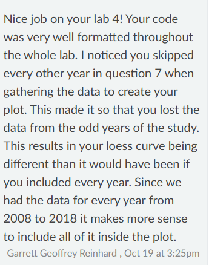

I am proud of this feedback because I noticed a subtle issue with their answer that affected the correctess of their plot and statistical analysis. I tend to miss small issues like these myself and it is hard to debug sometimes, so I try to catch them in others peoples work so that they have an easier time debugging their code later.

During the pair programming activities I have learned how to explain my ideas to my partner better as the weeks have progressed. Initially I found it hard to to work effectively because I couldn’t explain why something would work to someone that isn’t as experienced with programming as I am. I found that giving examples along with my proposed solution allowed my partner to better understand why we were doing something rather than just moving on because we got the correct answer. I think this is an important skill to keep improving on because being a more effective team member will eventually make it so that any team I am a part of will work more efficiently.